Fig & Co| i. Noraisha Yusuf (WQD180008)| ii.Low Tsu Siang (WQD180072)| iii.Kaveenaasvini (WQD180017)| Iv. Prabavathi (WQD180030)

December 13, 2018

#### A group assignment for WQD7001: Principle Data Science, University Malaya

> **Introduction**

Bike sharing culture is on the rise particularly in urban cities. Many urbanites have adopted this mode of transport. It provides an alternative means of travelling that is cheaper, healthier and environmentally friendly.

The City of Chicago launched Divvy, a new bike share system designed to connect people to transit, and to make short one-way trips across town easy. The Divvy bikes are gaining more popularity since its establishment in 2013.

> **Question**

The Divvy bikes has an impressive amount of 592 bike stations in Chicago city. We were particularly interested with the number of trips at these locations in 2017. When and where do bikers normally ride their rented Divvy bikes?

We believed that these information would be useful to bikers, nearby and new businesses and the bike rental company itself. In view that these interested parties would be driven by different motives, it is essential that the shiny app allows the users to explore the bike trips in accordance with their preferences. It is challenging to visualize the distribution of bike trips across the 592 Divvy bike stations. Hence, we opted to develop the Shiny App to produce a spatial/map visualization of the bike trips.

> **Goal**

In order to answer our questions, we have to map out and categorize the popularity of the bike stations based on:

- specific date
- time frame
- gender

*Note:* On this page, the focus is on describing our data preparation and exploratory data analysis. For the Shiny App codes, the ui.r and server.r files are available in the same github account.

> **Data Preparation**

We obtained the dataset from https://www.kaggle.com/yingwurenjian/chicago-divvy-bicycle-sharing-data. The same dataset can also be obtained directly from Divvy Bike Share’s website.

1. Load the data. In view that our focus is only for 2017, we subset the data by filtering the year column to 2017 only.

```r
bike <- read.csv("data.csv")
dataset <- subset(bike,bike$year == 2017)
```

2. A brief overview of the dataset.

```r
glimpse(dataset)
```

```
## Observations: 2,957,690
## Variables: 23
## $ trip_id           <int> 13518905, 13518904, 13518903, 13518902, 1351...
## $ year              <int> 2017, 2017, 2017, 2017, 2017, 2017, 2017, 20...
## $ month             <int> 3, 3, 3, 3, 3, 3, 3, 3, 3, 3, 3, 3, 3, 3, 3,...
## $ week              <int> 13, 13, 13, 13, 13, 13, 13, 13, 13, 13, 13, ...
## $ day               <int> 4, 4, 4, 4, 4, 4, 4, 4, 4, 4, 4, 4, 4, 4, 4,...
## $ hour              <int> 23, 23, 23, 23, 23, 23, 23, 23, 23, 23, 23, ...
## $ usertype          <fct> Subscriber, Subscriber, Subscriber, Subscrib...
## $ gender            <fct> Male, Male, Female, Male, Female, Male, Male...
## $ starttime         <fct> 2017-03-31 23:59:07, 2017-03-31 23:56:25, 20...
## $ stoptime          <fct> 2017-04-01 00:13:24, 2017-04-01 00:00:21, 20...
## $ tripduration      <dbl> 14.283333, 3.933333, 5.800000, 4.800000, 6.9...
## $ temperature       <dbl> 37.9, 37.9, 37.9, 37.9, 37.9, 37.9, 37.9, 37...
## $ events            <fct> cloudy, cloudy, cloudy, cloudy, cloudy, clou...
## $ from_station_id   <int> 66, 199, 520, 110, 327, 143, 81, 56, 210, 11...
## $ from_station_name <fct> Clinton St & Lake St, Wabash Ave & Grand Ave...
## $ latitude_start    <dbl> 41.88564, 41.89091, 42.01596, 41.89399, 41.9...
## $ longitude_start   <dbl> -87.64182, -87.62680, -87.66857, -87.62932, ...
## $ dpcapacity_start  <dbl> 23, 15, 23, 23, 19, 15, 39, 27, 19, 23, 23, ...
## $ to_station_id     <int> 171, 26, 432, 142, 331, 289, 41, 77, 69, 29,...
## $ to_station_name   <fct> May St & Cullerton St, McClurg Ct & Illinois...
## $ latitude_end      <dbl> 41.85514, 41.89102, 42.00907, 41.89450, 41.9...
## $ longitude_end     <dbl> -87.65413, -87.61730, -87.67419, -87.61785, ...
## $ dpcapacity_end    <dbl> 11, 31, 19, 31, 20, 19, 19, 31, 19, 15, 15, ...
```

3. There are no missing values found in the dataset.

```r
colSums(is.na(dataset))
```

```
##           trip_id              year             month              week
##                 0                 0                 0                 0
##               day              hour          usertype            gender
##                 0                 0                 0                 0
##         starttime          stoptime      tripduration       temperature
##                 0                 0                 0                 0
##            events   from_station_id from_station_name    latitude_start
##                 0                 0                 0                 0
##   longitude_start  dpcapacity_start     to_station_id   to_station_name
##                 0                 0                 0                 0
##      latitude_end     longitude_end    dpcapacity_end
##                 0                 0                 0
```

4. Aligning with our objective, we filtered the dataset further based on these variables
- stoptime: *the time when the bike trips end*
- to_station_name: *the name of the bike destination station*
- latitude_end: *part of the coordinates of the bike destination station*
- longitude_end: *part of the coordinates of the bike destination station*
- gender: *male or female bikers*

```r
dataset <- dataset[c(10,20,21,22,8)]
```

5. We separated the date and time from the variable stoptime into two columns respectively.

```r
dataset <- separate(dataset, stoptime, into=c("arr_date","time"),sep=" ")
head(dataset)
```

```
##           arr_date     time               to_station_name latitude_end
## 6537546 2017-04-01 00:13:24         May St & Cullerton St     41.85514
## 6537547 2017-04-01 00:00:21      McClurg Ct & Illinois St     41.89102
## 6537548 2017-04-01 00:01:21           Clark St & Lunt Ave     42.00907
## 6537549 2017-03-31 23:59:34          McClurg Ct & Erie St     41.89450
## 6537550 2017-04-01 00:00:28 Halsted St & Blackhawk St (*)     41.90854
## 6537551 2017-03-31 23:55:19         Wells St & Concord Ln     41.91213
##         longitude_end gender
## 6537546     -87.65413   Male
## 6537547     -87.61730   Male
## 6537548     -87.67419 Female
## 6537549     -87.61785   Male
## 6537550     -87.64863 Female
## 6537551     -87.63466   Male
```

6. For the purpose of our analysis, we extracted the arrival hour information from time variable

```r
dataset <- separate(dataset, time, into=c("arr_hour","min","sec"),sep=":")
dataset <- dataset[-c(3,4)]
```

7. Renamed columns

```r
colnames(dataset)[c(4,5)] <- c("latitude","longitude")
```

8. Created a new column that computes the total number of trips given a date, gender and destination station

```r
dataset$arr_date <- as.Date(dataset$arr_date)
dataset$arr_hour <- as.numeric(dataset$arr_hour)

dataset <- dataset %>%
  group_by(arr_date,arr_hour,to_station_name,latitude,longitude,gender) %>%
  summarise(total_trips = n())%>%
  glimpse()
```

```
## Observations: 1,537,545
## Variables: 7
## $ arr_date        <date> 2017-01-01, 2017-01-01, 2017-01-01, 2017-01-0...
## $ arr_hour        <dbl> 0, 0, 0, 0, 0, 0, 0, 0, 0, 0, 0, 0, 0, 0, 0, 0...
## $ to_station_name <fct> Ashland Ave & Augusta Blvd, Ashland Ave & Blac...
## $ latitude        <dbl> 41.89964, 41.90707, 41.96153, 41.95788, 41.957...
## $ longitude       <dbl> -87.66770, -87.66725, -87.69117, -87.64952, -8...
## $ gender          <fct> Male, Male, Male, Female, Male, Female, Male, ...
## $ total_trips     <int> 1, 1, 1, 1, 1, 1, 1, 1, 1, 1, 2, 1, 1, 1, 1, 1...
```

```r
summary(dataset)
```

```
##     arr_date             arr_hour                      to_station_name
##  Min.   :2017-01-01   Min.   : 0.00   Kingsbury St & Kinzie St :   9033
##  1st Qu.:2017-05-08   1st Qu.:10.00   Clinton St & Madison St  :   8773
##  Median :2017-07-17   Median :15.00   Dearborn St & Erie St    :   8575
##  Mean   :2017-07-11   Mean   :13.88   Clark St & Elm St        :   8264
##  3rd Qu.:2017-09-20   3rd Qu.:18.00   Wabash Ave & Roosevelt Rd:   8023
##  Max.   :2018-01-01   Max.   :23.00   Wells St & Concord Ln    :   7974
##                                       (Other)                  :1486903
##     latitude       longitude         gender         total_trips
##  Min.   :41.74   Min.   :-87.80   Female: 509183   Min.   : 1.000
##  1st Qu.:41.88   1st Qu.:-87.66   Male  :1028362   1st Qu.: 1.000
##  Median :41.90   Median :-87.65                    Median : 1.000
##  Mean   :41.90   Mean   :-87.65                    Mean   : 1.924
##  3rd Qu.:41.93   3rd Qu.:-87.63                    3rd Qu.: 2.000
##  Max.   :42.06   Max.   :-87.55                    Max.   :98.000
##
```

2. Visualizing distribution of total number of bike trips by gender factor in 2017.

We can observe that the peak number of trips is similar for both genders, form mid-June to October 2017. The bike trips for male can reached more than 10,000 bike trips in a day during peak season.

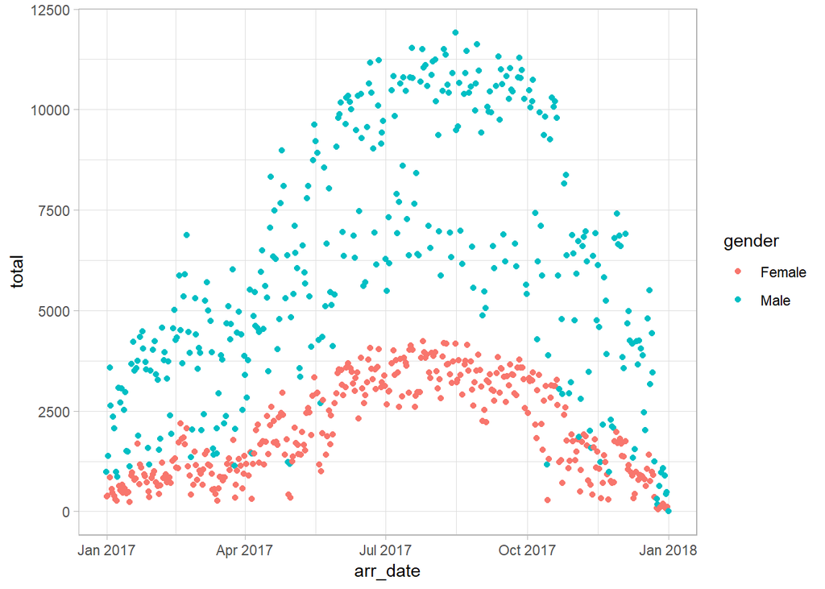

```r
library(ggplot2)

dately <- dataset %>%
  group_by(arr_date,gender) %>%
  summarise(total = sum(total_trips))


ggplot(dately, aes(x=arr_date,y=total))+
  geom_jitter(aes(color = gender))+
  theme_light()
```

3. Visualizing bike trips according to bike stations

This is a basic view using tree map approach. From the diagram, we can see the more popular destination bike stations are Canal St & Adams St, ClintonSt & Madison St, Clinton St & Washington Blvd, Kingsbury st & Kinzie St, Canal St & Madison St, Daisy Center Plaza, Micigan Ave & Washington St. and Franklin St & Monroe St.

```r
station <- dataset %>%
  group_by(to_station_name) %>%
  summarise(total = sum(total_trips))

sample_n(station, 10)
```

```
## # A tibble: 10 x 2
##    to_station_name                total
##    <fct>                          <int>
##  1 Valli Produce - Evanston Plaza   329
##  2 Albany Ave & 26th St             120
##  3 Loomis St & Jackson Blvd        4496
##  4 LaSalle St & Adams St          12519
##  5 Cicero Ave & Flournoy St           9
##  6 Racine Ave & Wrightwood Ave     4715
##  7 Marshfield Ave & 44th St          27
##  8 Clark St & Bryn Mawr Ave        3955
##  9 Millennium Park                12174
## 10 Blue Island Ave & 18th St       4786
```

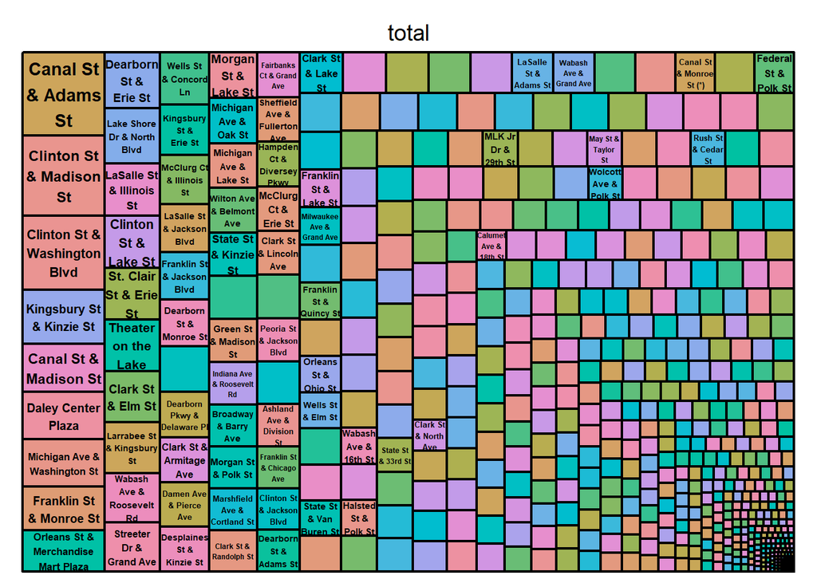

```r
library(treemap)

treemap(station,index = "to_station_name",vSize = "total")
```

4. Visualizing the peak number of bike trips by date

Majority of the high number of bike trips occurred between mid June up till October 2017. Hence, Summer to Autumn are the most preferred season to bike in Chicago.

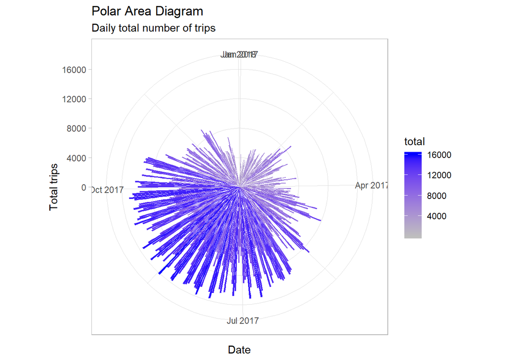

```r
dateterm <- dataset %>%
  group_by(arr_date) %>%
  summarise(total = sum(total_trips))

ggplot(dateterm, aes(x=arr_date,y=total,fill=total))+
  geom_bar(stat = "identity") +
  scale_fill_gradient(low="gray", high="blue") +
  theme_light()+
  coord_polar()+
  labs(title="Polar Area Diagram", subtitle="Daily total number of trips", x="Date", y="Total trips")
```

5. Visualizing the number of trips around the 24 hours duration

Majority preferred to bike around 7-8 am and 4-6 pm. The highest number of bike trips happened around 8 am and 5 pm. Although minimal, there are some bike trips nearing midnight time. This would be useful information to bike share company to ensure that their bikes are safe for use during late night time.

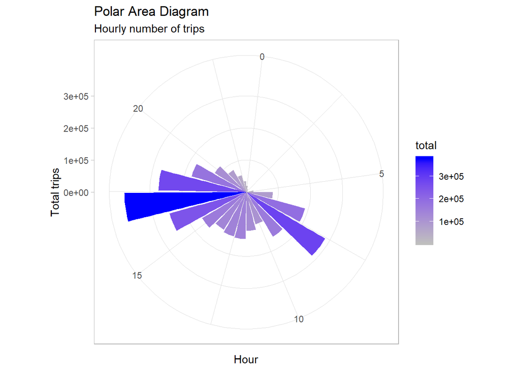

```r
hourly <- dataset%>%
  group_by(arr_hour)%>%
  summarise(total = sum(total_trips))


ggplot(hourly, aes(x=arr_hour,y=total,fill=total))+
  geom_bar(stat="identity") +
  theme_light()+
  coord_polar()+
  scale_fill_gradient(low="gray", high="blue") +
  labs(title="Polar Area Diagram", subtitle="Hourly number of trips", x="Hour", y="Total trips")
```

A quick look at the Grab a Bike app

[figure not shown]

capture

*Note:* Please refer to the ui.r and server.r files which are available in the same github account, for the Shiny App construction.